# Sierra: Extracting transcript isoform use from single cell RNAseq

Ralph Patrick, David Humphreys and Kitty Lo

Genomics Core, Victor Chang Cardiac Research Institute  
School of Mathematics and Statistics, University of Sydney

November 27, 2019

#### Abstract

This vignette provides walkthroughs on how to install to use geneSlicer on single cell RNAseq data that enriches poly(A) transcripts (i.e. a 3’ targetted protocol).

# 1 Introduction

Single cell RNA sequencing is a powerful technology that is utilised to extract gene expression information from thousands of cells. While there are a number of described single cell RNA-Seq methods many are based on the principle of capturing and sequencing the 3’ end of transcripts.

Many bioinformatic principles of single cell RNA seq are applied from bulk RNA-Seq methods. This includes building a gene count matrix from which secondary analysis can be performed on. This matrix is built by counting sequence reads and assigning them to specific genes when they fall within exonic coordinates of existing gene models. Genes that have multiple transcript isoforms are collapsed and counts are accumulated. Geneslicer resolves transcript isoform usage at the gene level….

# 2 Quickstart

STEP1: Install SIERRA from github

```
install.packages("devtools")
library(devtools)
devtools::install_github("VCCRI/Sierra", build = TRUE, build_opts = c("--no-resave-data", "--no-manual"))
```

# 3 Preparing input data sets

## 3.1 Required inputs

### 3.1.1 BAM file

BAM files should be created from CellRanger or an equivalent program. Sierra requires BAM files to include two meta-data field tags, unique molecular identifier (UMI tag `UB:Z`) and cell barcode (tag `CB:Z`), which enables cell type identification and peak quantification.

### 3.1.2 Splice junctions file

A BED formatted file that represents splice junctions that occur within the BAM file. This file can be created using the regtools program which needs to be run from your system command line. Below is an example of command line syntax that will generate the required output file. Note for the purposes of this vignette this step can be skipped as both output files, `Vignette_example_TIP_sham_junctions.bed` and `Vignette_example_TIP_MI_junctions.bed`, have already been precomputed.

```
# The following are system commands to run regtools.
# BAM file from Sham
regtools junctions extract Vignette_example_TIP_sham.bam -o Vignette_example_TIP_sham_junctions.bed
# BAM file from myocardial infarction
regtools junctions extract Vignette_example_TIP_MI.bam -o Vignette_example_TIP_MI_junctions.bed
```

### 3.1.3 Reference annotation file

The Sierra pipeline requires a gene transfer formatted (GTF) file. Ideally this should be same GTF as provided in the alignment step. If CellRanger was used to align the data use the `genes.gtf` file contained within the CellRanger reference package.

For this vignette a reduced GTF file has been provided that only contains a subset of genes. Similarly a reduced BAM file and peak file have also been created. Finally a white list of barcodes that identify single cells is also required. The following R code define the location of the vignette example files.

```
extdata_path <- system.file("extdata",package = "sierra")
reference.file <- paste0(extdata_path,"/Vignette_cellranger_genes_subset.gtf")
junctions.file <- paste0(extdata_path,"/Vignette_example_TIP_sham_junctions.bed")
bamfile <- c(paste0(extdata_path,"/Vignette_example_TIP_sham.bam"),
            paste0(extdata_path,"/Vignette_example_TIP_MI.bam") )
whitelist.bc.file <- c(paste0(extdata_path,"/example_TIP_sham_whitelist_barcodes.tsv"),
            paste0(extdata_path,"/example_TIP_MI_whitelist_barcodes.tsv"))
```

# 4 Pipeline

Peak calling >> merging >> counting >> visualisation

## 4.1 Peak calling

Peak calling is performed on each BAM file. As previously mentioned a number of files are required to perform this task.

```
peak.output.file <- c("Vignette_example_TIP_sham_peaks.txt",
                      "Vignette_example_TIP_MI_peaks.txt")
FindPeaks(output.file = peak.output.file[1],   # output filename
          gtf.file = reference.file,           # gene model as a GTF file
          bamfile = bamfile[1],                # BAM alignment filename.
          junctions.file = junctions.file,     # BED filename of splice junctions exising in BAM file.
          ncores = 4)                          # number of cores (only effective on mac and linux)


FindPeaks(output.file = peak.output.file[2],   # output filename
          gtf.file = reference.file,           # gene model as a GTF file
          bamfile = bamfile[2],                # BAM alignment filename.
          junctions.file = junctions.file,     # BED filename of splice junctions exising in BAM file.
          ncores = 4)                          # number of cores (only effective on mac and linux)
```

The FindPeaks function will print status updates as shown below as it progresses through the data file.

Import genomic features from the file as a GRanges object … OK  
Prepare the ‘metadata’ data frame … OK  
Make the TxDb object … OK  
15 gene entries to process  
There are 202 unfiltered sites and 201 filtered sites  
There are 201 sites following duplicate removal

## 4.2 Peak merging

If you have multiple samples and therefore BAM files, run FindPeaks on each BAM individually. A unified set of peak coorindates from all samples can be then created using the MergePeakCoordinates function. This step can utilise multithreading (except windows users).

```
### Read in the tables, extract the peak names and run merging ###

peak.dataset.table = data.frame(Peak_file = peak.output.file,
  Identifier = c("TIP-example-Sham", "TIP-example-MI"),
  stringsAsFactors = FALSE)

peak.merge.output.file = "TIP_merged_peaks.txt"
MergePeakCoordinates(peak.dataset.table, output.file = peak.merge.output.file, ncores = 4)
```

## 4.3 Counting per peak

After you finish peak calling, you will have a file with the peak location information and we can now recount the data to create a per peak counts table. The code below may take a few minutes to run.

```
count.dirs <- c("example_TIP_sham_counts", "example_TIP_MI_counts")

#sham data set
CountPeaks(peak.sites.file = peak.merge.output.file,
           gtf.file = reference.file,
           bamfile = bamfile[1],
           whitelist.file = whitelist.bc.file[1],
           output.dir = count.dirs[1],
           countUMI = TRUE,
           ncores = 4)

# MI data set
CountPeaks(peak.sites.file = "TIP_merged_peaks.txt",
           gtf.file = reference.file,
           bamfile = bamfile[2],
           whitelist.file = whitelist.bc.file[2],
           output.dir = count.dirs[2],
           countUMI = TRUE,
           ncores = 4)
```

## 4.4 Aggregate multiple count data-sets

```
# As previously defined
peak.merge.output.file <- "TIP_merged_peaks.txt"
count.dirs <- c("example_TIP_sham_counts", "example_TIP_MI_counts")


# New definition
out.dir <- "example_TIP_aggregate"

# Now aggregate the counts for both sham and MI treatments
AggregatePeakCounts(peak.sites.file = peak.merge.output.file,
                    count.dirs = count.dirs,
                    exp.labels = c("Sham", "MI"),
                    output.dir = out.dir)
```

## 4.5 Annotate peaks

Finally we want to annotate the peaks for genomic features. This is done using the AnnotatePeaksFromGTF function. As part of annotation involves motif matching, we need to load a genome. This can be installed from Bioconductor. For human download BSgenome.HSapiens.UCSC.hg38 and for mouse download BSgenome.Mmusculus.UCSC.mm10

```
# The following commands will install genome packages onto your local computer. These packages are large and may take a little time to download (depending on network speed)


if (!requireNamespace("BiocManager", quietly = TRUE))
    install.packages("BiocManager")

# Mouse genome
BiocManager::install("BSgenome.Mmusculus.UCSC.mm10")

# Human genome
BiocManager::install("BSgenome.Hsapiens.UCSC.hg38")
```

We are now ready to input the peak coordinates to annotate. For this example we used the output from MergePeakCoordinates, But if you only have one sample to analyse use the output from FindPeaks.

```
# As previously defined
peak.merge.output.file <- "TIP_merged_peaks.txt"
extdata_path <- system.file("extdata",package = "sierra")
reference.file <- paste0(extdata_path,"/Vignette_cellranger_genes_subset.gtf")


# New definitions
genome <- BSgenome.Mmusculus.UCSC.mm10::BSgenome.Mmusculus.UCSC.mm10

AnnotatePeaksFromGTF(peak.sites.file = peak.merge.output.file,
                     gtf.file = reference.file,
                     output.file = "TIP_merged_peak_annotations.txt",
                     genome = genome)
```

## 4.6 Detecting and visualising differential transcript usage

For differential usage testing we first create an object to hold the peak count and annotation information. Sierra can interface with either Seurat or the Bioconductor Single-Cell Experiment (SCE) class. Once the peak object has been created, the same functions will work with either a Seurat or SCE based object. Here we will demonstrate the main Sierra functions using Seurat - see below for creating a Sierra object with SCE.

```
library(Seurat)

# Previous definitions
out.dir <- "example_TIP_aggregate"
extdata_path <- system.file("extdata",package = "sierra")

## Read in the counts
peak.counts <- ReadPeakCounts(data.dir = out.dir)

## Read in peak annotations
peak.annotations <- read.table("TIP_merged_peak_annotations.txt",
                               header = TRUE,
                               sep = "\t",
                               row.names = 1,
                               stringsAsFactors = FALSE)
head(peak.annotations)

# Load precompiled gene-level object called 'genes.seurat'
load(paste0(extdata_path,"/TIP_vignette_gene_Seurat.RData"))

## Create peak-level Seurat object
## Since we're using a reduced matrix need to set min.cells and
## min.peaks to 0 or else everything gets filtered out
peaks.seurat <- PeakSeuratFromTransfer(peak.data = peak.counts,
                                       genes.seurat = genes.seurat,
                                       annot.info = peak.annotations,
                                       min.cells = 0, min.peaks = 0)
```

An alternative is to create a new object. If cluster IDs and dimensionality reduction coordinates are available they can be passed to the object - which we will do for this example. This isn’t neccessary if you want to try clustering using the peak counts

```
load(paste0(extdata_path,"/TIP_cell_info.RData"))
peaks.seurat <- NewPeakSeurat(peak.data = peak.counts,
                              annot.info = peak.annotations,
                              cell.idents = tip.populations,
                              tsne.coords = tip.tsne.coordinates,
                              min.cells = 0, min.peaks = 0)
```

t-SNE plot of populations can be drawn using the DimPlot function from Seurat

```
DimPlot(peaks.seurat, reduction = 'tsne', label = TRUE, pt.size = 0.5)
```

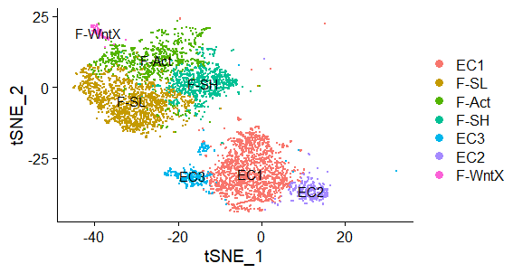

Figure 1: Dimplot output

## 4.7 Differential expression analysis

Differential peak usage analysis is performed with DEXSeq. To perform differential usage testing, the main function is DUTest. This takes in the peaks object and either a population ID or a list of cell barcode IDs. population.2 can be left unspecified and the function will test for population.1 vs everything else. For this test we’ll just compare the two biggest fibrobalst and EC clusters

```
res.table = DUTest(peaks.seurat,
                   population.1 = "F-SL",
                   population.2 = "EC1",
                   exp.thresh = 0.1,
                   feature.type = c("UTR3", "exon"))
```

DUTest filters results according to a default adjusted P-value threshold (0.05) and log2 fold-change threshold (0.25) prior to returning the results. These thresholds can be modified, or we can subset the results data-frame for the top results.

```
res.table.top <- subset(res.table, abs(Log2_fold_change) > 1)
head(res.table.top)
```

The top gene coming up is Cxcl12. For this gene, two peaks are coming up as significant. We will plot them compared to the gene expression.

```
peaks.to.plot <- rownames(subset(res.table.top, gene_name == "Cxcl12"))

# First let's look at what the gene expression looks like
Seurat::FeaturePlot(genes.seurat, "Cxcl12", cols = c("lightgrey", "red"))
```

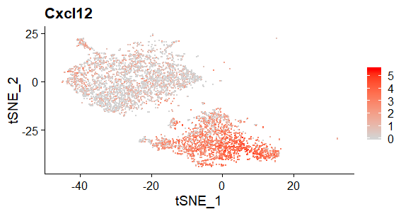

Now plot relative expression of the peaks.

```
PlotRelativeExpressionTSNE(peaks.seurat, peaks.to.plot = peaks.to.plot)
```

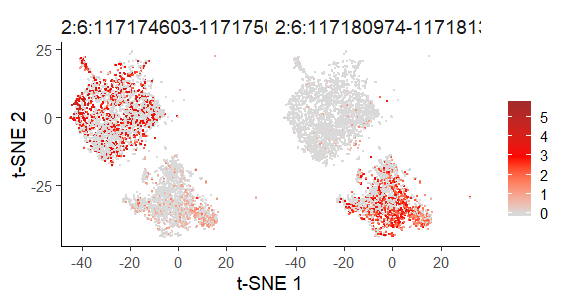

Figure 2: PlotRelativeExpressionTSNE output

Sometimes only one peak will be called as significant. If you want to compare to other peaks they can be retrieved for plotting using the SelectGenePeaks function

```
all.peaks <- SelectGenePeaks(peaks.seurat, gene = "Cxcl12", feature.type = c("UTR3", "exon"))
```

Sierra has 4 functions for plotting relative expression:

PlotRelativeExpressionTSNE PlotRelativeExpressionUMAP PlotRelativeExpressionBox PlotRelativeExpressionViolin

### 4.7.1 Sierra PlotRelativeExpressionBox

Let’s see what a box plot looks like

[figure not shown]

Figure 3: PlotRelativeExpressionBox output

## 4.8 Plot coverage

Next we want to see what these peaks correspond to. For that use the PlotCoverage function

First we need to extract the relevant cell populations from the aggregate BAM file Note that extracting cell populations can be memory consuming when extracting a large number of cells. An alternative is to extract specific genes to plot, or to extract using smaller numbers of cells then merging the BAM files together. Here we will extract a gene to plot for comparing a combination of fibroblast and EC populations.

```
Condition <- data.frame(Condition = sub(".*-(.*)", "\\1", colnames(peaks.seurat)),
                        row.names = colnames(peaks.seurat))
peaks.seurat <- AddMetaData(peaks.seurat, metadata = Condition, col.name = "Condition")

peaks.seurat <- subset(peaks.seurat, subset = Condition == "Sham")
cells.df <- as.data.frame(Idents(peaks.seurat))
cells.df$cellbc = rownames(cells.df)
colnames(cells.df) <- c("celltype", "cellbc")
```

Make sure cell barcodes match what is in the original BAM file

```
cells.df$cellbc <- sub("(.*)-.*", "\\1", cells.df$cellbc)
cells.df$cellbc <- paste0(cells.df$cellbc, "-1")

cells.df <- subset(cells.df, celltype %in% c("F-SL", "F-SH", "EC1", "EC2", "EC3"))
cells.df$celltype <- droplevels(cells.df$celltype)
cells.df$celltype <- plyr::mapvalues(cells.df$celltype,
                                     from=c("F-SL", "F-SH", "EC1", "EC2", "EC3"),
                                     to=c("Fibroblast", "Fibroblast", "EC", "EC", "EC"))




outdir = "bam_subsets/"
dir.create(outdir)
SplitBam(bamfile[1], cells.df, outdir)
```

Alternatively to extract for a single gene

```
gtf_gr <- rtracklayer::import(reference.file)
SplitBam(bam = bamfile[1],
         cellbc.df = cells.df,
         outdir = outdir,
         gtf_gr = gtf_gr,
         geneSymbol = "Cxcl12")
```

Now we have the cell type-specific BAMs, we can plot read coverage across a gene between the fibroblast and ECs. This is done using the PlotCoverage function

```
# First define BAM files in order of plotting
bam.files <- paste0(outdir, c("Fibroblast.Cxcl12.bam", "EC.Cxcl12.bam"))

## Now run the PlotCoverage function
PlotCoverage(genome_gr = gtf_gr,
             geneSymbol = "Cxcl12",
             genome = "mm10",
             bamfiles = bam.files)

## For larger genes and more cells it can be best to send the output straight to PDF
## To do this set pdf_output = TRUE and specify output_file_name
PlotCoverage(genome_gr = gtf_gr,
             geneSymbol = "Cxcl12",
             genome = "mm10",
             pdf_output = TRUE,
             bamfiles = bam.files,
             output_file_name = "Cxcl12_fibroblast_vs_ECs example.pdf")
```

## 4.9 Working with the Single-Cell Experiment class

```
Read in the counts

peak.counts <- ReadPeakCounts(data.dir = "example_TIP_aggregate")

## Read in peak annotations
peak.annotations <- read.table("TIP_merged_peak_annotations.txt",
                               header = TRUE,
                               sep = "\t",
                               row.names = 1,
                               stringsAsFactors = FALSE)

## Input is the same as for using the NewPeakSeurat function
load(paste0(extdata_path,"/TIP_cell_info.RData"))
peaks.sce <- NewPeakSCE(peak.data = peak.counts,
                        annot.info = peak.annotations,
                        cell.idents = tip.populations,
                        tsne.coords = tip.tsne.coordinates,
                        min.cells = 0, min.peaks = 0)

## the DUTest and visualisation functions are run the same as above
res.table = DUTest(peaks.sce, population.1 = "F-SL", population.2 = "EC1",
                   exp.thresh = 0.1, feature.type = c("UTR3", "exon"))

res.table.top <- subset(res.table, abs(Log2_fold_change) > 1)
head(res.table.top)

## Relative expression plot
PlotRelativeExpressionTSNE(peaks.sce, peaks.to.plot = peaks.to.plot)

## Selecting peaks according to gene
all.peaks <- SelectGenePeaks(peaks.sce, gene = "Cxcl12", feature.type = c("UTR3", "exon"))
print(all.peaks)

## Relative expression box plot
PlotRelativeExpressionBox(peaks.sce, peaks.to.plot = peaks.to.plot)
```